# Transformasi Data

## Sebaran Peubah Acak

### Pembangkitan bilangan acak

Pembangkitan bilangan acak merupakan alat yang diperlukan dalam komputasi statistik, umumnya untuk simulasi. Bilangan acak yang dibangkitkan merupakan *pseudorandom* yang memenuhi sebaran statistik tertentu seperti fungsi massa peluang atau fungsi kepekatan peluang dan fungsi sebaran kumulatif.

Semua metode pembangkitan bilangan acak tergantung dari pembangkitan bilangan acak seragam.

Sebagai salah satu bahasa pemrograman yang hadir karena kebutuhan akan komputasi statistik, R telah menyiapkan banyak fungsi untuk membangkitkan data berdasarkan sebaran. Fungsi peluang suatu sebaran dalam R ditandai dengan prefix sebagai berikut:

| Prefix | Deskripsi |
| --- | --- |
| `r-` | pembangkitan bilangan acak dari suatu sebaran |
| `d-` | pdf $f(x)$ / pmf $P(X=x)$ |
| `p-` | cdf $P(X \le x)$ |
| `q-` | fungsi quantile/invers cdf |

### Fungsi Sebaran

R dilengkapi dengan sekumpulan fungsi untuk membangkitkan bilangan acak sebaran peluang yang umum digunakan seperti sebaran normal, poisson, binomial dan lain-lain. Beberapa contoh fungsi untuk membangkitkan data yang berasal dari sebaran tertentu antara lain [(Peng 2020)](https://bookdown.org/rdpeng/rprogdatascience/):

| Distribution | R name | Arguments |
| --- | --- | --- |
| beta | `beta` | shape1, shape2, ncp |
| binomial | `binom` | size, prob |
| Chauchy | `cauchy` | location, scale |
| chi-squared | `chisq` | df, ncp |
| exponential | `exp` | rate |
| F | `f` | df1, df2, ncp |
| gamma | `gamma` | shape, scale |
| geometric | `geom` | prob |
| hypergeometric | `hyper` | m, n, k |
| log-normal | `lnorm` | meanlog, sdlog |
| uniform | `unif` | min, max |
| neg binomial | `nbinom` | size, prob |
| normal | `norm` | mean, sd |
| Poisson | `pois` | lambda |
| Student’s t | `t` | df, ncp |

#### Fungsi sebaran peluang diskret

| Fungsi | Deskripsi |
| --- | --- |
| `-binom` | sebaran binomial $Bi(n, \lambda)$ |
| `-hyper` | sebaran hipergeometrik $H(N, m, n)$ |
| `-nbinom` | sebaran binomial negatif $NB(k, pi)$ |
| `-pois` | sebaran Poisson $Po(\lambda, t)$ |

#### Fungsi sebaran peluang kontinu

| Fungsi | Deskripsi |
| --- | --- |
| `-unif` | sebaran seragam $U(a, b)$ |
| `-exp` | sebaran eksponensial $Exp(\lambda)$ |
| `-norm` | sebaran normal $N(\pi, \sigma)$ |

## Transformasi Data

Banyak metode statistika yang mensyaratkan bahwa peubah numerik yang digunakan harus mengikuti sebaran normal. Contohnya: uji-T pada Uji signifikansi parameter model regresi atau uji-F pada ANOVA

Asumsi bahwa data berdistribusi normal dengan ragam yang homogen harus selalu diperiksa, Jika asumsi terpenuhi maka kita dapat menganalisis data tersebut dengan analisis statistika parametrik. Namun jika tidak, maka perlu dilakukan penanganan terhadap data tersebut.

Transformasi data dapat **memperbaiki** penyimpangan dari normalitas dan keragaman yang tidak homogen (heteroskedastisitas). Transformasi yang tepat memungkinkan kita menggunakan analisis statistika parametrik.

## Asumsi 1: Normalitas

### Membangkitkan data

Membangkitkan data simulasi yang menyebar secara simetris (Normal)

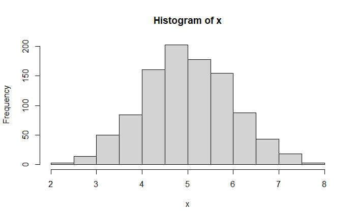

```r
# data menyebar normal
x <- rnorm(1000, 5, 1)
hist(x)
```

Dapat dilihat bahwa sebaran data simulasi yang kita bangkitkan berdasarkan QQPlot sudah sesuai karena secara umum setiap amatan berada pada garis Normal

[figure not shown]

```r
#data menyebar normal
qqnorm(x)
qqline(x,col=2)
```

Perhatikan pada data menyebar normal, nilai mean dan median cenderung mirip

```r
summary(x)
```

```
   Min. 1st Qu.  Median    Mean 3rd Qu.    Max.
  2.027   4.339   4.978   4.992   5.660   7.967
```

### Uji kenormalan Shapiro-Wilk

```r
shapiro.test(x)
```

[output not shown]

*Hipotesis:*

- $H_0$: data menyebar normal
- $H_1$: data tidak menyebar normal

Karena `p-value` = 0.7389 > taraf nyata 0.05, maka dapat disimpulkan bahwa *data menyebar normal*, pada uji dengan taraf 5%.

Berikutnya, dibangkitkan suatu data menggunakan sebaran chi-square untuk dilakukan uji kenormalan.

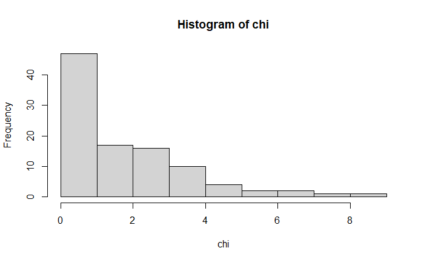

```r
#data tidak menyebar normal
chi <- rchisq(100, 2, 0)

# tahapan 1: histogram
hist(chi)
```

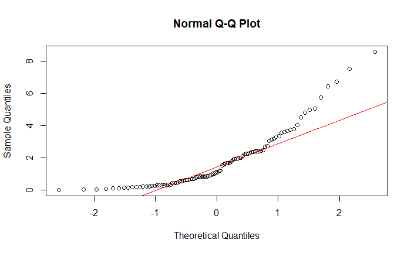

```r
# tahapan 2: qqplot
qqnorm(chi)
qqline(chi, col="red")
```

```r
# tahapan 3: Uji kenormalan Shapiro-Wilk
shapiro.test(chi)
```

```
    Shapiro-Wilk normality test

data:  chi
W = 0.83634, p-value = 3.831e-09
```

Bagaimana jika sebaran tersebut ditransformasi $x = x^{1/3}$. Proses ini mungkin memerlukan percobaan untuk mendapatkan hasil yang sesuai.

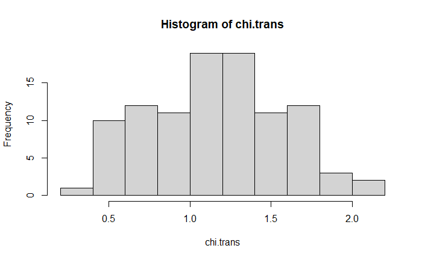

```r
chi.trans<-chi^(1/3)
hist(chi.trans)
```

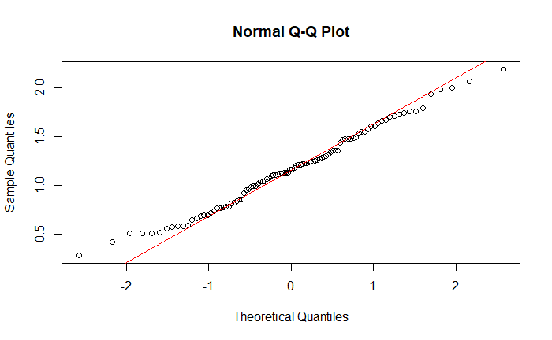

```r
qqnorm(chi.trans)
qqline(chi.trans, col="red")
```

```r
shapiro.test(chi.trans)
```

```
    Shapiro-Wilk normality test

data:  chi.trans
W = 0.98697, p-value = 0.4355
```

## Asumsi 2: Heteroskedastisitas

Asumsi lainnya yang penting adalah ragam Homogen. Kehomogenan ragam dapat kita lihat melalui plot residual/sisaan. Jika ragam homogen, maka pada plot residual, sisaan akan bersifat acak dengan memusat di sekitar nilai 0 dengan simpangan baku tertentu dan tidak terdapat pola-pola hubungan tertentu (misal pola berbentuk corong). Jika ingin menggunakan ukuran tertentu, adpat pula dilakukan uji seperti Uji Breusch-Pagan (BP), white atau Uji Glejser.

### Ilustrasi

```r
set.seed(7)
x <- rep(seq(1, 5, ), each=10)
e <- c()
for (i in 1:5) {
    e0 <- rnorm(10, 0, 0.5*i)
    e <- c(e, e0)
}

y <- 15+(4*x)+e

mod <- lm(y~x)
res <- residuals(mod)
fits <- fitted(mod)
```

[figure not shown]

```r
par(mfrow=c(1,2))
plot(fits, res)
plot(x, y)
```

Pola sisaan memperlihatkan adanya ketidakhomogenan ragam.

## Power Transform

Dengan teknik *power transforms*, transformasi peubah `x` dan `y` dengan *monotonic with inflection point* lalu periksa kembali pola sisaan.

$X = X^{-1} = 1/X$

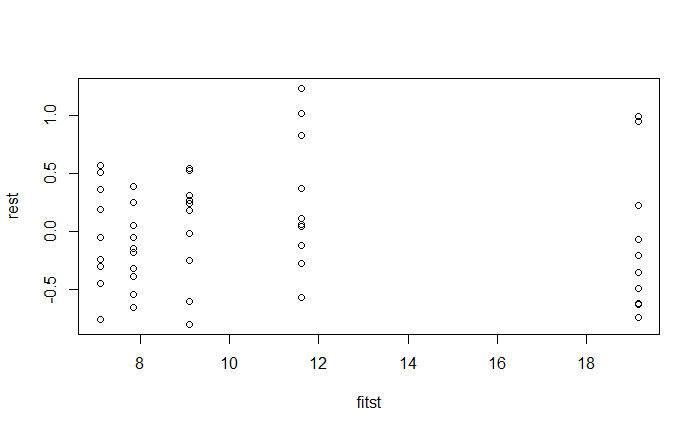

```r
xt <- 1/x
yt <- y/x

modt <- lm(yt~xt)
rest <- residuals(modt)
fitst <- fitted(modt)

plot(fitst,rest)
```

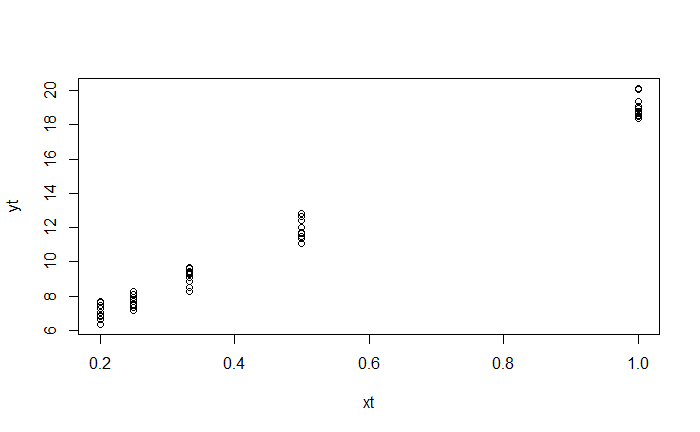

```r
plot(xt,yt)
```

### Ilustrasi

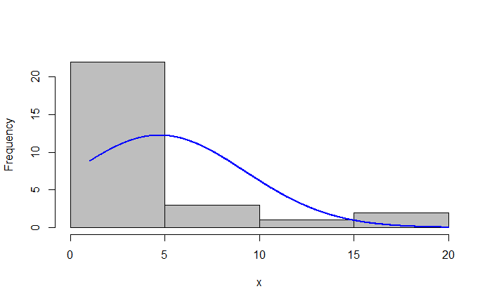

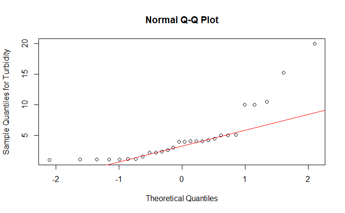

```r
qqnorm(Turbidity, ylab="Sample Quantiles for Turbidity")
qqline(Turbidity, col="red")
```

## Transformasi dengan Metode Tukey

Perintah `transformTukey` dari *package* `rcompanion` dapat digunakan untuk melakukan transformasi tukey. pada package ini, nilai lambda ditentukan batas bawah dan atas. Fungsi akan melakukan proses pencarian secara iteratif untuk memperoleh nilai terbaik dalam proses transformasi.

```r
Transf_tukey <- transformTukey(Turbidity, plotit = F)
```

|  | lambda | W | Shapiro.p.value |
| --- | --- | --- | --- |
| 397 | -0.1 | 0.935 | 0.08248 |

```
if (lambda >  0){TRANS = x ^ lambda}
if (lambda == 0){TRANS = log(x)}
if (lambda <  0){TRANS = -1 * x ^ lambda}
```

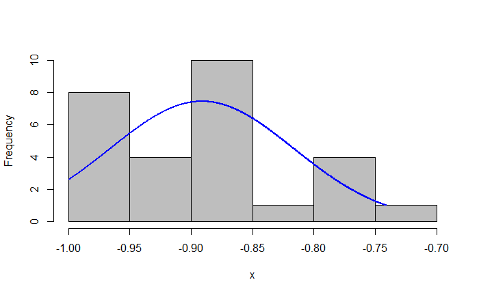

## Transformasi Box-Cox

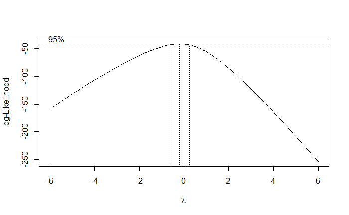

```r
# transfomasi boxcox pada data turbidity
# dengan rentang nilai lambda = [-6, -5.9, ..., 5.9, 6]
Trans_box <- boxcox(
  Turbidity ~ 1,
  lambda = seq(-6, 6, 0.1)
)
```

```r
Trans_box
```

```
$x
  [1] -6.0 -5.9 -5.8 -5.7 -5.6 -5.5 -5.4 -5.3 -5.2 -5.1 -5.0 -4.9 -4.8 -4.7 -4.6
 [16] -4.5 -4.4 -4.3 -4.2 -4.1 -4.0 -3.9 -3.8 -3.7 -3.6 -3.5 -3.4 -3.3 -3.2 -3.1
 [31] -3.0 -2.9 -2.8 -2.7 -2.6 -2.5 -2.4 -2.3 -2.2 -2.1 -2.0 -1.9 -1.8 -1.7 -1.6
 [46] -1.5 -1.4 -1.3 -1.2 -1.1 -1.0 -0.9 -0.8 -0.7 -0.6 -0.5 -0.4 -0.3 -0.2 -0.1
 [61]  0.0  0.1  0.2  0.3  0.4  0.5  0.6  0.7  0.8  0.9  1.0  1.1  1.2  1.3  1.4
 [76]  1.5  1.6  1.7  1.8  1.9  2.0  2.1  2.2  2.3  2.4  2.5  2.6  2.7  2.8  2.9
 [91]  3.0  3.1  3.2  3.3  3.4  3.5  3.6  3.7  3.8  3.9  4.0  4.1  4.2  4.3  4.4
[106]  4.5  4.6  4.7  4.8  4.9  5.0  5.1  5.2  5.3  5.4  5.5  5.6  5.7  5.8  5.9
[121]  6.0

$y
  [1] -158.14312 -155.45283 -152.77215 -150.10135 -147.44069 -144.79045 -142.15090
  [8] -139.52237 -136.90517 -134.29963 -131.70610 -129.12495 -126.55658 -124.00138
 [15] -121.45978 -118.93226 -116.41927 -113.92132 -111.43896 -108.97275 -106.52328
 [22] -104.09120 -101.67719  -99.28196  -96.90628  -94.55097  -92.21690  -89.90502
 [29]  -87.61631  -85.35185  -83.11280  -80.90040  -78.71599  -76.56101  -74.43703
 [36]  -72.34575  -70.28902  -68.26885  -66.28745  -64.34724  -62.45085  -60.60123
 [43]  -58.80159  -57.05550  -55.36695  -53.74033  -52.18056  -50.69310  -49.28404
 [50]  -47.96015  -46.72893  -45.59866  -44.57840  -43.67799  -42.90799  -42.27950
 [57]  -41.80405  -41.49321  -41.35829  -41.40988  -41.65736  -42.10843  -42.76867
 [64]  -43.64123  -44.72664  -46.02283  -47.52527  -49.22731  -51.12061  -53.19556
 [71]  -55.44176  -57.84848  -60.40495  -63.10065  -65.92553  -68.87010  -71.92551
 [78]  -75.08357  -78.33675  -81.67812  -85.10136  -88.60065  -92.17071  -95.80665
 [85]  -99.50404 -103.25875 -107.06704 -110.92544 -114.83074 -118.78001 -122.77051
 [92] -126.79973 -130.86534 -134.96518 -139.09725 -143.25972 -147.45084 -151.66905
 [99] -155.91284 -160.18085 -164.47180 -168.78449 -173.11782 -177.47076 -181.84233
[106] -186.23164 -190.63785 -195.06017 -199.49786 -203.95024 -208.41665 -212.89649
[113] -217.38918 -221.89420 -226.41102 -230.93919 -235.47823 -240.02774 -244.58731
[120] -249.15655 -253.73512
```

```r
# buat data frame dari hasil Trans_box
cox <- data.frame(Trans_box$x, Trans_box$y)
cox
```

| Trans_box.x | Trans_box.y |
| --- | --- |
| -6.0 | -158.14312 |
| -5.9 | -155.45283 |
| -5.8 | -152.77215 |
| -5.7 | -150.10135 |
| -5.6 | -147.44069 |
| -5.5 | -144.79045 |
| -5.4 | -142.15090 |
| -5.3 | -139.52237 |
| -5.2 | -136.90517 |
| -5.1 | -134.29963 |

[output cut: 111 more lines]

```r
# urutkan data frame tersebut secara menurun pada kolom y
cox2 <- cox[with(cox, order(-cox$Trans_box.y)),]
cox2
```

|  | Trans_box.x | Trans_box.y |
| --- | --- | --- |
| 59 | -0.2 | -41.35829 |
| 60 | -0.1 | -41.40988 |
| 58 | -0.3 | -41.49321 |
| 61 | 0.0 | -41.65736 |
| 57 | -0.4 | -41.80405 |
| 62 | 0.1 | -42.10843 |
| 56 | -0.5 | -42.27950 |
| 63 | 0.2 | -42.76867 |
| 55 | -0.6 | -42.90799 |
| 64 | 0.3 | -43.64123 |

[output cut: 111 more lines]

Dapat dilihat bahwa lambda yang memiliki nilai log-likelihood paling tinggi adalah -0.2.

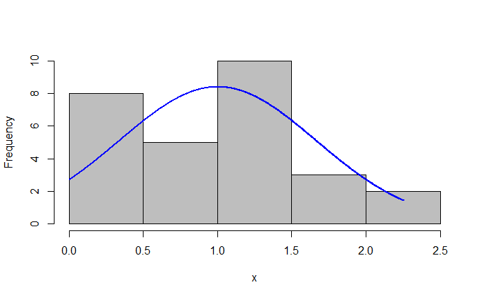

### Ilustrasi

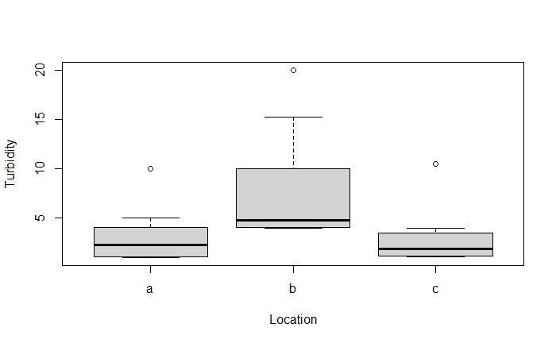

```r
model_turbidity <- lm(Turbidity ~ Location, ilustrasi)
car::Anova(model_turbidity, type="II")
```

```
Anova Table (Type II tests)

Response: Turbidity
          Sum Sq Df F value  Pr(>F)
Location  132.63  2  3.8651 0.03447 *
Residuals 428.95 25
---
Signif. codes:  0 ‘***’ 0.001 ‘**’ 0.01 ‘*’ 0.05 ‘.’ 0.1 ‘ ’ 1
```

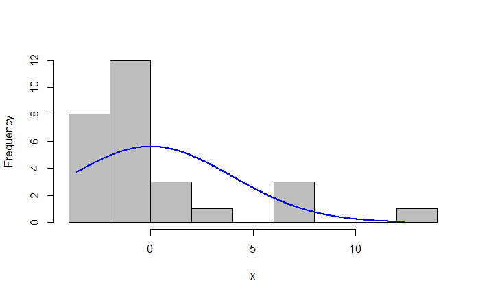

```r
z <- residuals(model_turbidity)
plotNormalHistogram(z)
```

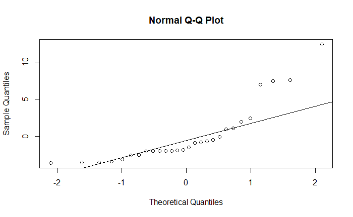

```r
qqnorm(z)
qqline(z)
```

|  | lambda | W | Shapiro.p.value |
| --- | --- | --- | --- |
| 397 | -0.1 | 0.935 | 0.08248 |

```
if (lambda >  0){TRANS = x ^ lambda}
if (lambda == 0){TRANS = log(x)}
if (lambda <  0){TRANS = -1 * x ^ lambda}
```

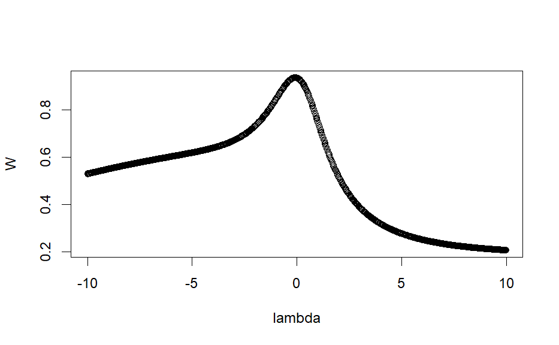

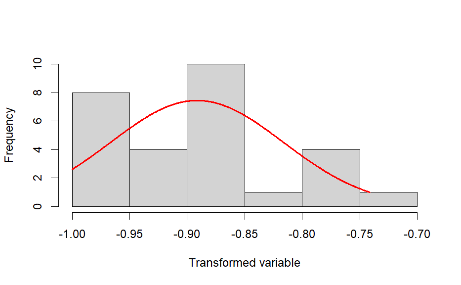

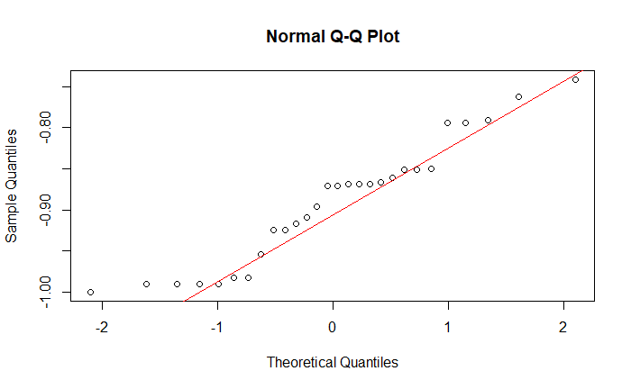

```r
ilustrasi$Turbidity_tukey <- transformTukey(ilustrasi$Turbidity, plotit = T)
```

```r
ilustrasi$Turbidity_boxcox <- Trans_box_with_lambda
```

```r
# lakukan uji kenormalan setelah transformasi
model_turbidity_box <- lm(Turbidity_boxcox ~ Location, ilustrasi)
car::Anova(model_turbidity_box, type="II")
```

```
Anova Table (Type II tests)

Response: Turbidity_boxcox
          Sum Sq Df F value Pr(>F)
Location  4.1643  2  6.6929 0.0047 **
Residuals 7.7774 25
---
Signif. codes:  0 ‘***’ 0.001 ‘**’ 0.01 ‘*’ 0.05 ‘.’ 0.1 ‘ ’ 1
```

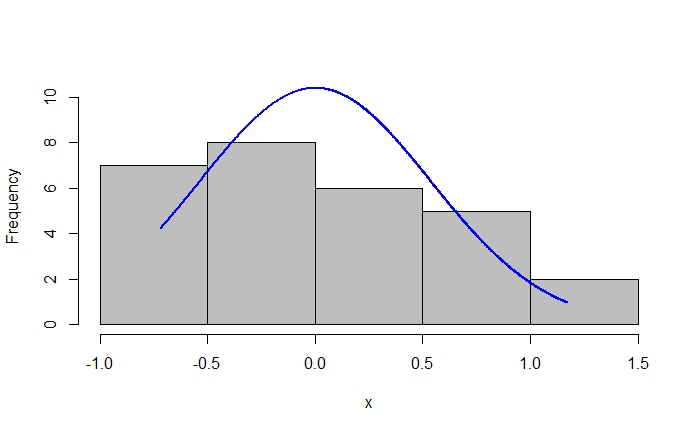

```r
zt <- residuals(model_turbidity_box)
plotNormalHistogram(zt)
```

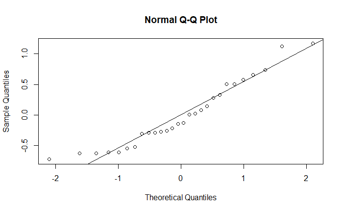

```r
qqnorm(zt)
qqline(zt)
```

## Ilustrasi dengan dataset `cars`

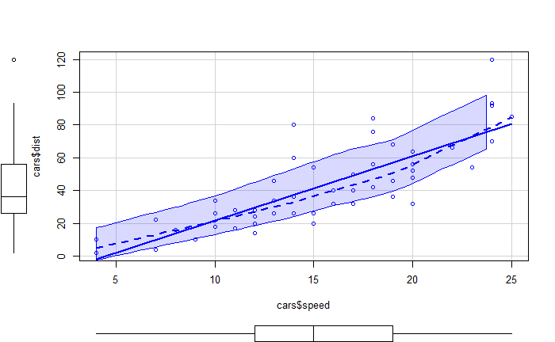

```r
car::scatterplot(cars$speed, cars$dist)
```

```r
mdl <- lm(dist~speed, data=cars)
summary(mdl)
```

```
Call:
lm(formula = dist ~ speed, data = cars)

Residuals:
    Min      1Q  Median      3Q     Max
-29.069  -9.525  -2.272   9.215  43.201

Coefficients:
            Estimate Std. Error t value Pr(>|t|)
(Intercept) -17.5791     6.7584  -2.601   0.0123 *
speed         3.9324     0.4155   9.464 1.49e-12 ***
---
Signif. codes:  0 ‘***’ 0.001 ‘**’ 0.01 ‘*’ 0.05 ‘.’ 0.1 ‘ ’ 1

Residual standard error: 15.38 on 48 degrees of freedom
Multiple R-squared:  0.6511,    Adjusted R-squared:  0.6438
F-statistic: 89.57 on 1 and 48 DF,  p-value: 1.49e-12
```

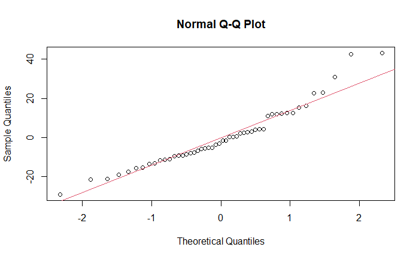

```r
sisaan <- residuals(mdl)
qqnorm(sisaan)
qqline(sisaan, col=2)
```

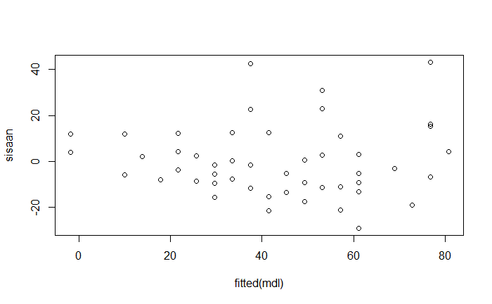

```r
plot(fitted(mdl), sisaan)
```

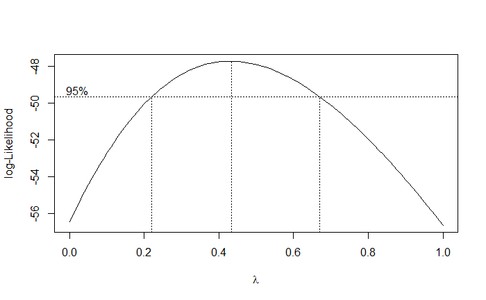

```r
boxcox(mdl, lambda=seq(0,1,by=.1))
```

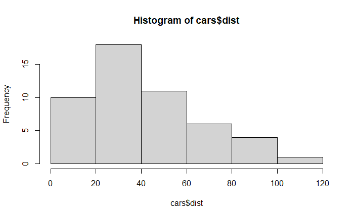

```r
hist(cars$dist)
```

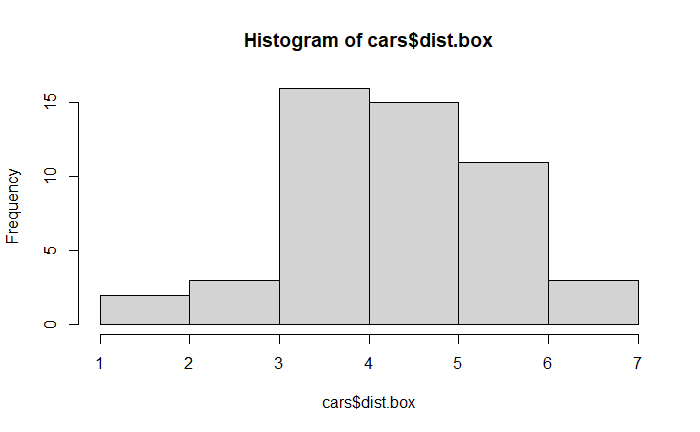

```r
# Pemodelan regresi linear dengan transformasi Box-Cox
cars$dist.box<-cars$dist^0.4
hist(cars$dist.box)
```

```r
model.box<-lm(dist.box~speed,data=cars)
summary(model.box)
```

```
Call:
lm(formula = dist.box ~ speed, data = cars)

Residuals:
    Min      1Q  Median      3Q     Max
-1.1274 -0.3846 -0.1140  0.2936  1.7369

Coefficients:
            Estimate Std. Error t value Pr(>|t|)
(Intercept)  1.48232    0.27135   5.463 1.64e-06 ***
speed        0.18225    0.01668  10.925 1.29e-14 ***
---
Signif. codes:  0 ‘***’ 0.001 ‘**’ 0.01 ‘*’ 0.05 ‘.’ 0.1 ‘ ’ 1

Residual standard error: 0.6175 on 48 degrees of freedom
Multiple R-squared:  0.7132,    Adjusted R-squared:  0.7072
F-statistic: 119.4 on 1 and 48 DF,  p-value: 1.294e-14
```

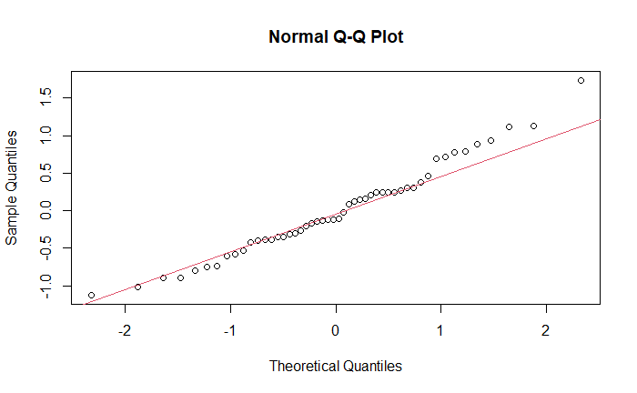

```r
qqnorm(residuals(model.box))
qqline(residuals(model.box),col=2)
```

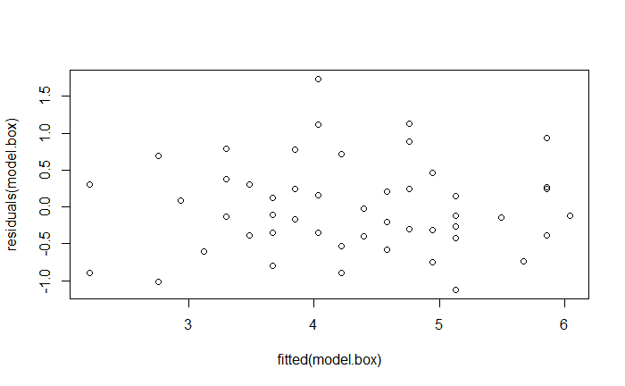

```r
plot(fitted(model.box),residuals(model.box))
```

Apakah transformasi memperbaiki pemodelan regresi?